# R Notebook

**Principles of Data Visualization and Introduction to ggplot2**

I have provided you with data about the 5,000 fastest growing companies in the US, as compiled by Inc. magazine. lets read this in:

```r
library(ggplot2)
library(tidyr)
library(dplyr)
inc <- read.csv("https://raw.githubusercontent.com/charleyferrari/CUNY_DATA_608/master/module1/Data/inc5000_data.csv", header= TRUE)
```

And lets preview this data:

```r
head(inc)
```

|  | Rank | Name | Growth_Rate | Revenue | Industry | Employees | City | State |
| --- | --- | --- | --- | --- | --- | --- | --- | --- |
| 1 | 1 | Fuhu | 421.48 | 1.179e+08 | Consumer Products & Services | 104 | El Segundo | CA |
| 2 | 2 | FederalConference.com | 248.31 | 4.960e+07 | Government Services | 51 | Dumfries | VA |
| 3 | 3 | The HCI Group | 245.45 | 2.550e+07 | Health | 132 | Jacksonville | FL |
| 4 | 4 | Bridger | 233.08 | 1.900e+09 | Energy | 50 | Addison | TX |
| 5 | 5 | DataXu | 213.37 | 8.700e+07 | Advertising & Marketing | 220 | Boston | MA |
| 6 | 6 | MileStone Community Builders | 179.38 | 4.570e+07 | Real Estate | 63 | Austin | TX |

```r
summary(inc)
```

```
      Rank                          Name       Growth_Rate         Revenue                                  Industry      Employees                  City
 Min.   :   1   (Add)ventures         :   1   Min.   :  0.340   Min.   :2.000e+06   IT Services                 : 733   Min.   :    1.0   New York     : 160
 1st Qu.:1252   @Properties           :   1   1st Qu.:  0.770   1st Qu.:5.100e+06   Business Products & Services: 482   1st Qu.:   25.0   Chicago      :  90
 Median :2502   1-Stop Translation USA:   1   Median :  1.420   Median :1.090e+07   Advertising & Marketing     : 471   Median :   53.0   Austin       :  88
 Mean   :2502   110 Consulting        :   1   Mean   :  4.612   Mean   :4.822e+07   Health                      : 355   Mean   :  232.7   Houston      :  76
 3rd Qu.:3751   11thStreetCoffee.com  :   1   3rd Qu.:  3.290   3rd Qu.:2.860e+07   Software                    : 342   3rd Qu.:  132.0   San Francisco:  75
 Max.   :5000   123 Exteriors         :   1   Max.   :421.480   Max.   :1.010e+10   Financial Services          : 260   Max.   :66803.0   Atlanta      :  74
                (Other)               :4995                                         (Other)                     :2358   NA's   :12        (Other)      :4438
     State
 CA     : 701
 TX     : 387
 NY     : 311
 VA     : 283
 FL     : 282
 IL     : 273
 (Other):2764
```

Think a bit on what these summaries mean. Use the space below to add some more relevant non-visual exploratory information you think helps you understand this data:

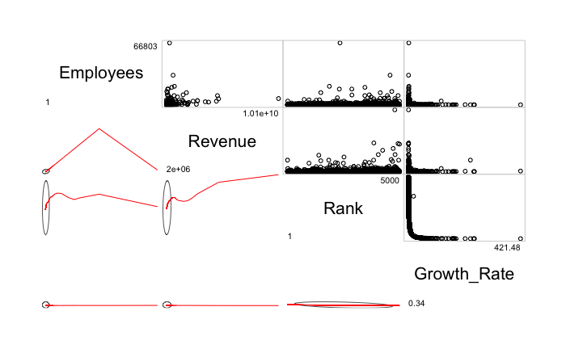

```r
library(corrgram)
corrgram(inc, order=TRUE, lower.panel=panel.ellipse,
  upper.panel=panel.pts, text.panel=panel.txt,
  diag.panel=panel.minmax)
```

```r
summary(lm(Employees ~ Revenue, data = inc))
```

```
Call:
lm(formula = Employees ~ Revenue, data = inc)

Residuals:
   Min     1Q Median     3Q    Max
 -9130   -148   -128    -74  66211

Coefficients:
             Estimate Std. Error t value Pr(>|t|)
(Intercept) 1.574e+02  1.877e+01   8.384   <2e-16 ***
Revenue     1.562e-06  7.643e-08  20.432   <2e-16 ***
---
Signif. codes:  0 ‘***’ 0.001 ‘**’ 0.01 ‘*’ 0.05 ‘.’ 0.1 ‘ ’ 1

Residual standard error: 1300 on 4987 degrees of freedom
  (12 observations deleted due to missingness)
Multiple R-squared:  0.07725,   Adjusted R-squared:  0.07706
F-statistic: 417.5 on 1 and 4987 DF,  p-value: < 2.2e-16
```

## Question 1

Create a graph that shows the distribution of companies in the dataset by State (ie how many are in each state). There are a lot of States, so consider which axis you should use. This visualization is ultimately going to be consumed on a ‘portrait’ oriented screen (ie taller than wide), which should further guide your layout choices.

```r
state = inc %>%
  group_by(State) %>%
  count(State)%>%
  arrange(desc(n))
head(state)
```

| State | n |
| --- | --- |
| CA | 701 |
| TX | 387 |
| NY | 311 |
| VA | 283 |
| FL | 282 |
| IL | 273 |

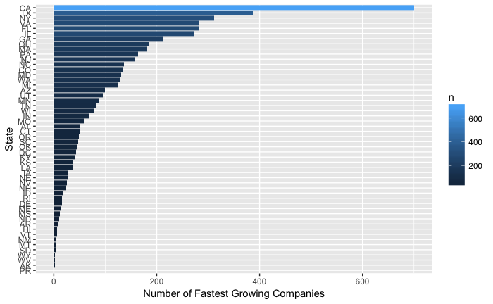

```r
f <- ggplot(state, aes(x=reorder(State, n), y=n, fill=n))
f + geom_bar(stat="identity") + coord_flip()+ labs(x = "State", y = "Number of Fastest Growing Companies")
```

## Quesiton 2

Lets dig in on the state with the 3rd most companies in the data set. Imagine you work for the state and are interested in how many people are employed by companies in different industries. Create a plot that shows the average and/or median employment by industry for companies in this state (only use cases with full data, use R’s `complete.cases()` function.) In addition to this, your graph should show how variable the ranges are, and you should deal with outliers.

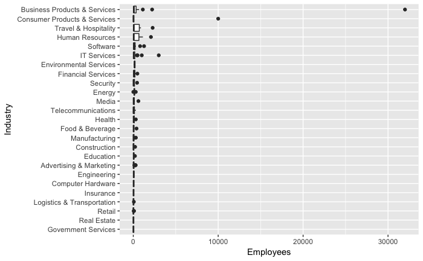

```r
inc <- inc[complete.cases(inc),]
ny = inc %>%
  filter(State == "NY")
g <- ggplot(ny, aes(reorder(Industry,Employees,mean), Employees))
g <- g + geom_boxplot() + coord_flip() + labs(x = "Industry", y = "Employees")
g
```

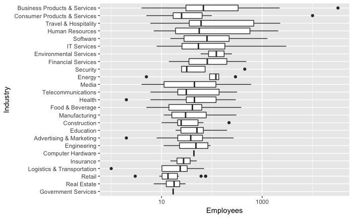

```r
g + scale_y_log10()
```

## Removing Outliers

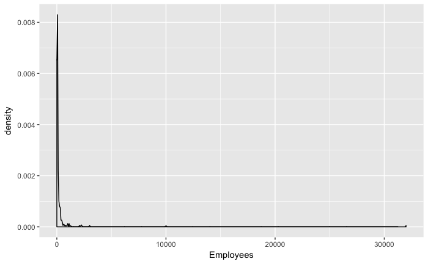

```r
c <- ggplot(ny, aes(Employees))
c + geom_density(kernel = "gaussian")
```

```r
summary(ny$Employees)
```

```
   Min. 1st Qu.  Median    Mean 3rd Qu.    Max.
    1.0    21.0    45.0   271.3   105.5 32000.0
```

```r
head(ny %>% arrange(desc(Employees)))
```

|  | Rank | Name | Growth_Rate | Revenue | Industry | Employees | City | State |
| --- | --- | --- | --- | --- | --- | --- | --- | --- |
| 1 | 4577 | Sutherland Global Services | 0.48 | 5.976e+08 | Business Products & Services | 32000 | Pittsford | NY |
| 2 | 4936 | Coty | 0.36 | 4.600e+09 | Consumer Products & Services | 10000 | New York | NY |
| 3 | 4716 | Westcon Group | 0.44 | 3.800e+09 | IT Services | 3000 | Tarrytown | NY |
| 4 | 3899 | Denihan Hospitality Group | 0.71 | 2.808e+08 | Travel & Hospitality | 2280 | New York | NY |
| 5 | 4363 | TransPerfect | 0.55 | 3.413e+08 | Business Products & Services | 2218 | New York | NY |
| 6 | 1499 | Sterling Infosystems | 2.66 | 2.149e+08 | Human Resources | 2081 | New York | NY |

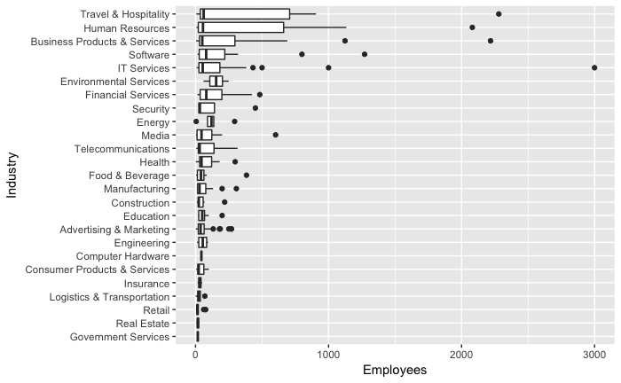

```r
ny_no_outliers = ny %>%
  filter(Employees <= 3000)
g <- ggplot(ny_no_outliers, aes(reorder(Industry,Employees,mean), Employees))
g <- g + geom_boxplot() + coord_flip() + labs(x = "Industry", y = "Employees")
g
```

## Question 3

Now imagine you work for an investor and want to see which industries generate the most revenue per employee. Create a chart that makes this information clear. Once again, the distribution per industry should be shown.

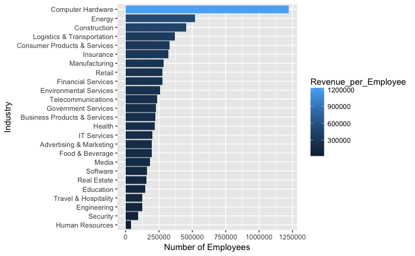

```r
inc <- inc[complete.cases(inc),]
industry_emp = inc %>%
  group_by(Industry) %>%
  summarise(Revenue=sum(Revenue), Employees=sum(Employees)) %>%
  mutate(Revenue_per_Employee = Revenue/Employees)
d <- ggplot(industry_emp, aes(x=reorder(Industry, Revenue_per_Employee), y=Revenue_per_Employee, fill=Revenue_per_Employee))
d + geom_bar(stat="identity") + coord_flip() + labs(x = "Industry", y = "Number of Employees")
```

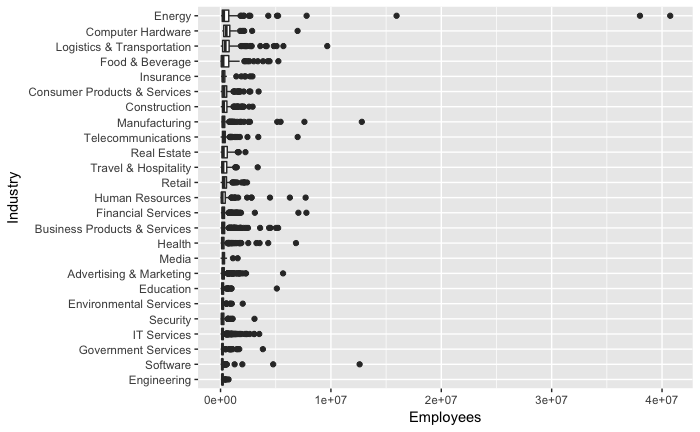

```r
rev_emp = inc %>%
  mutate(Revenue_per_Employee = Revenue/Employees)
h <- ggplot(rev_emp, aes(reorder(Industry,Revenue_per_Employee,mean), Revenue_per_Employee))
h <- h + geom_boxplot() + coord_flip() + labs(x = "Industry", y = "Employees")
h
```

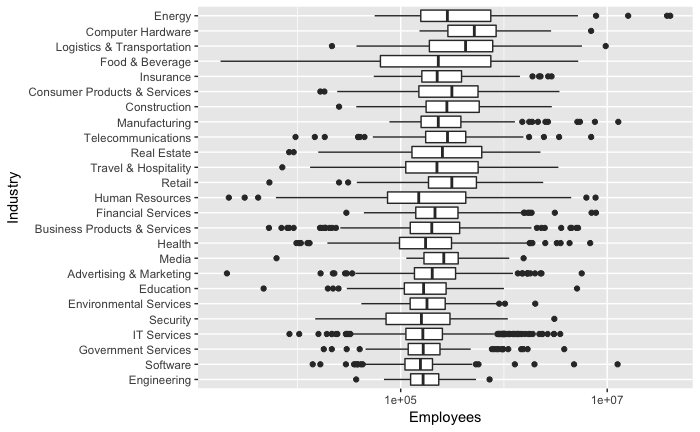

```r
h + scale_y_log10()
```